# 5-2. 데이터 분석 2차 - 라벨링

```python
import pandas as pd
import numpy as np
import matplotlib.pyplot as plt
import seaborn as sns
# 경고메세지 무시
import warnings
warnings.filterwarnings('ignore')
```

```python
# # 모든 행 출력
# pd.set_option('display.max_rows',None)
```

```python
import pickle

with open("dataV3_processed.pickle","rb") as fr:
    df = pickle.load(fr)
df.head()
```

| matchId | gameDuration | assists | championName | damageDealtToObjectives | damageDealtToTurrets | damageSelfMitigated | deaths | dragonKills | kills | magicDamageDealtToChampions | ... | teamPosition | timeCCingOthers | totalDamageDealtToChampions | totalDamageShieldedOnTeammates | totalDamageTaken | totalHealsOnTeammates | totalMinionsKilled | trueDamageDealtToChampions | visionScore | win |
| --- | --- | --- | --- | --- | --- | --- | --- | --- | --- | --- | --- | --- | --- | --- | --- | --- | --- | --- | --- | --- | --- |
| KR_5944529373 | 1548 | 2 | Trundle | 10809 | 8068 | 14206 | 4 | 1 | 4 | 2200 | ... | TOP | 16 | 17912 | 0 | 22268 | 0 | 199 | 1251 | 11 | False |
| KR_5944529373 | 1548 | 5 | Viego | 12425 | 647 | 13265 | 5 | 0 | 3 | 1112 | ... | JUNGLE | 14 | 10543 | 0 | 20618 | 0 | 37 | 799 | 24 | False |
| KR_5944529373 | 1548 | 1 | Katarina | 4894 | 0 | 13089 | 6 | 0 | 7 | 14299 | ... | MIDDLE | 1 | 19362 | 0 | 22430 | 0 | 142 | 426 | 20 | False |
| KR_5944529373 | 1548 | 2 | Tristana | 334 | 248 | 8841 | 6 | 0 | 5 | 1986 | ... | BOTTOM | 2 | 10721 | 0 | 19263 | 0 | 168 | 588 | 24 | False |
| KR_5944529373 | 1548 | 9 | Nautilus | 5165 | 0 | 21768 | 7 | 0 | 0 | 4585 | ... | UTILITY | 59 | 7656 | 536 | 19286 | 0 | 32 | 461 | 48 | False |

5 rows × 22 columns

```python
df.columns # 컬럼명 확인
```

```
Index(['gameDuration', 'assists', 'championName', 'damageDealtToObjectives',
       'damageDealtToTurrets', 'damageSelfMitigated', 'deaths', 'dragonKills',
       'kills', 'magicDamageDealtToChampions', 'neutralMinionsKilled',
       'physicalDamageDealtToChampions', 'teamPosition', 'timeCCingOthers',
       'totalDamageDealtToChampions', 'totalDamageShieldedOnTeammates',
       'totalDamageTaken', 'totalHealsOnTeammates', 'totalMinionsKilled',
       'trueDamageDealtToChampions', 'visionScore', 'win'],
      dtype='object')
```

### 1. 탑

#### 컬럼 선택

- 오브젝트 관련 컬럼 제외: damageDealtToObjectives, dragonKills
- 서포팅 관련 컬럼 제외: totalDamageShieldedOnTeammates, totalHealsOnTeammates, visionScore
- 목적변수 제외: win
- 인덱스: teamPosition, championName

```python
# 컬럼 제외
df_top = df[df['teamPosition']=='TOP']
df_top = df_top.drop(['teamPosition','damageDealtToObjectives','dragonKills','totalDamageShieldedOnTeammates',
                      'totalHealsOnTeammates','visionScore','win'],axis=1)
df_top.head() # 컬럼 14개(챔피언 이름 제외)
```

| matchId | gameDuration | assists | championName | damageDealtToTurrets | damageSelfMitigated | deaths | kills | magicDamageDealtToChampions | neutralMinionsKilled | physicalDamageDealtToChampions | timeCCingOthers | totalDamageDealtToChampions | totalDamageTaken | totalMinionsKilled | trueDamageDealtToChampions |
| --- | --- | --- | --- | --- | --- | --- | --- | --- | --- | --- | --- | --- | --- | --- | --- |
| KR_5944529373 | 1548 | 2 | Trundle | 8068 | 14206 | 4 | 4 | 2200 | 8 | 14460 | 16 | 17912 | 22268 | 199 | 1251 |
| KR_5944529373 | 1548 | 4 | Gwen | 6365 | 15666 | 3 | 6 | 7393 | 6 | 3012 | 5 | 14367 | 18134 | 163 | 3961 |
| KR_5944532797 | 1858 | 8 | Olaf | 9360 | 49735 | 7 | 11 | 222 | 20 | 23887 | 14 | 34440 | 32154 | 195 | 10330 |
| KR_5944532797 | 1858 | 2 | Garen | 6040 | 32634 | 7 | 3 | 862 | 8 | 6957 | 20 | 12143 | 29997 | 197 | 4323 |
| KR_5944532993 | 2094 | 8 | Malphite | 754 | 49377 | 5 | 2 | 13080 | 3 | 2098 | 32 | 15861 | 24626 | 176 | 683 |

```python
# 컬럼명 저장
with open("cols_top.pickle","wb") as fw:
    pickle.dump(df_top.drop('championName',axis=1).columns, fw)
```

```python
len(df_top) # 탑 챔피언 행 수
```

```
217008
```

```python
# 데이터 정규화
from sklearn.preprocessing import StandardScaler
x_top = df_top.drop('championName',axis=1).values # 분석에 사용될 값
columns = df_top.drop('championName',axis=1).columns

scaler_top = StandardScaler()
scaler_top.fit(x_top)
x_top = scaler_top.transform(x_top) # 표준화
pd.DataFrame(x_top, columns=columns).head() # 표준화된 데이터 확인
```

|  | gameDuration | assists | damageDealtToTurrets | damageSelfMitigated | deaths | kills | magicDamageDealtToChampions | neutralMinionsKilled | physicalDamageDealtToChampions | timeCCingOthers | totalDamageDealtToChampions | totalDamageTaken | totalMinionsKilled | trueDamageDealtToChampions |
| --- | --- | --- | --- | --- | --- | --- | --- | --- | --- | --- | --- | --- | --- | --- |
| 0 | -1.220826 | 0.125358 | 0.976969 | -0.974488 | -0.810689 | -0.470487 | -0.658666 | -0.365311 | 0.210457 | -0.482532 | -0.514675 | -0.892535 | 0.256011 | -0.318830 |
| 1 | -1.220826 | 0.693903 | 0.509019 | -0.902558 | -1.146611 | 0.035788 | -0.106175 | -0.536579 | -0.976671 | -1.108966 | -0.868846 | -1.276648 | -0.598304 | 0.553652 |
| 2 | -0.097262 | 1.830992 | 1.331985 | 0.775923 | 0.197077 | 1.301476 | -0.869108 | 0.662294 | 1.188013 | -0.596429 | 1.136587 | 0.026027 | 0.161087 | 2.604145 |
| 3 | -0.097262 | 0.125358 | 0.419715 | -0.066594 | 0.197077 | -0.723625 | -0.801017 | -0.365311 | -0.567585 | -0.254738 | -1.091039 | -0.174392 | 0.208549 | 0.670198 |
| 4 | 0.758097 | 1.830992 | -1.032773 | 0.758285 | -0.474767 | -0.976762 | 0.498873 | -0.793481 | -1.071451 | 0.428645 | -0.719585 | -0.673441 | -0.289801 | -0.501697 |

```python
# PCA 분석
from sklearn.decomposition import PCA
pcColumns = np.arange(1,11)
pca = PCA(n_components=10) # 주성분 10개
printcipalComponents = pca.fit(x_top)

print('각 설명변수별 설명력:',pca.explained_variance_ratio_)
print('총 설명력:',pca.explained_variance_ratio_.sum()) # 주성분의 갯수를 늘릴수록 100에 가까워짐
```

```
각 설명변수별 설명력: [0.30944439 0.14838616 0.10411162 0.07508496 0.07030889 0.06889947
 0.0557395  0.04789622 0.04059763 0.03476418]
총 설명력: 0.9552330185454929
```

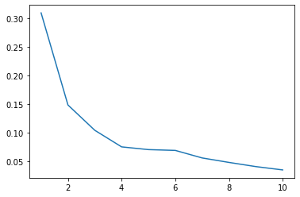

```python
# scree plot
# 주성분을 몇개로 할지 결정
sns.lineplot(x=pcColumns, y=pca.explained_variance_ratio_)
plt.show()
```

scree plot의 기울기가 급격히 감소하는 지점인 4개로 결정

```python
# 향후 챔피언별 통계값의 차원 축소를 위한 PCA객체
pca_top = PCA(n_components=4)
pca_top.fit(x_top)
print('각 설명변수별 설명력:',pca_top.explained_variance_ratio_)
print('총 설명력:',pca_top.explained_variance_ratio_.sum())
```

```
각 설명변수별 설명력: [0.30944439 0.14838616 0.10411162 0.07508496]
총 설명력: 0.6370271229921292
```

4개의 주성분의 총 설명력은 63.7%로 모든 데이터의 모든 의미를 완벽히 반영하진 못한다. 그러나 데이터들 사이엔 별로 중요하지 않은 요소들도 분명 존재하며, 주성분 분석이 이들까지 완벽히 반영해야 한단 뜻은 결코 아니다. 주성분 분석이 모델 설계에 유효한 기법이었는지는 모델의 성능으로써 입증될 것이다.

```python
# 챔피언별 통계
df_top_champ = df_top.groupby('championName').mean()
df_top_champ.head()
```

| championName | gameDuration | assists | damageDealtToTurrets | damageSelfMitigated | deaths | kills | magicDamageDealtToChampions | neutralMinionsKilled | physicalDamageDealtToChampions | timeCCingOthers | totalDamageDealtToChampions | totalDamageTaken | totalMinionsKilled | trueDamageDealtToChampions |
| --- | --- | --- | --- | --- | --- | --- | --- | --- | --- | --- | --- | --- | --- | --- |
| Aatrox | 1870.234781 | 0.721412 | 3359.149806 | 36468.403267 | 6.235587 | 5.806901 | 85.311919 | 14.264669 | 22479.194491 | 23.385173 | 22966.852831 | 36167.877884 | 180.908505 | 401.989232 |
| Ahri | 1931.901639 | 1.754098 | 2890.754098 | 12800.770492 | 6.163934 | 5.081967 | 14386.721311 | 5.868852 | 1730.377049 | 23.754098 | 21143.278689 | 23751.803279 | 185.245902 | 5025.114754 |
| Akali | 1896.761460 | 1.254960 | 2258.669327 | 20192.462942 | 6.280730 | 7.397263 | 21266.350057 | 4.096921 | 1627.360775 | 2.052223 | 24388.775599 | 30254.386089 | 173.928848 | 1494.233067 |
| Akshan | 1891.491379 | 1.623563 | 4760.790230 | 19535.660920 | 7.327586 | 7.791667 | 3777.445402 | 12.622126 | 19730.636494 | 2.683908 | 25914.649425 | 24201.715517 | 188.135057 | 2405.622126 |
| Alistar | 1853.413793 | 5.275862 | 1814.000000 | 54742.172414 | 6.000000 | 2.413793 | 11842.103448 | 2.586207 | 2305.241379 | 65.344828 | 14938.965517 | 33645.000000 | 134.827586 | 790.724138 |

```python
# 챔피언별 통계 데이터 정규화 -> PCA
x_top = df_top_champ.values # 분석에 사용될 값
columns = ['top_pc1','top_pc2','top_pc3','top_pc4']
index = df_top_champ.index

x_top = scaler_top.transform(x_top) # fit 되어있는 스케일러로 표준화
x_top = pca_top.transform(x_top) # fit 되어있는 PCA객체로 차원 축소

x_top = pd.DataFrame(data=x_top, columns=columns, index=index)
x_top.head()
```

| championName | top_pc1 | top_pc2 | top_pc3 | top_pc4 |
| --- | --- | --- | --- | --- |
| Aatrox | 0.137657 | -0.457733 | -0.976063 | 0.609607 |
| Ahri | -1.009953 | 0.373419 | 0.776129 | -0.823153 |
| Akali | -0.898934 | 0.673146 | 0.978793 | -1.167322 |
| Akshan | -0.164548 | -1.423406 | -0.333577 | -0.512223 |
| Alistar | -0.930829 | 2.755171 | -0.039095 | 1.768006 |

위의 차원축소 결과만 봐서는 각 컬럼들이 어떤 의미를 갖는지 짐작조차 불가능하다. 이를 시각화하여 확인하기 위해 위 데이터로 클러스터링을 진행해보았다.

```python
from sklearn.cluster import KMeans
from sklearn.metrics import silhouette_score
```

```python
# 비주류 챔피언 제외
import pickle
with open("label_top.pickle","rb") as fr:
    label_top = pickle.load(fr)
top_major = label_top[label_top['top_minor']==0].index
top_major # 주류 챔피언 리스트
```

```
Index(['Aatrox', 'Darius', 'Gangplank', 'Fiora', 'Renekton', 'Irelia', 'Gnar',
       'Camille', 'Sett', 'Mordekaiser', 'Jayce', 'Yone', 'Ornn', 'Jax',
       'Akali', 'Gwen', 'Shen', 'Malphite', 'Garen', 'Kayle', 'Gragas',
       'Teemo', 'Shyvana', 'Maokai', 'Volibear', 'Sejuani', 'Vayne', 'Riven',
       'Illaoi', 'Rumble', 'Sylas', 'Lillia', 'Udyr', 'Kennen', 'Nasus',
       'Olaf', 'Yorick', 'Poppy', 'Warwick', 'DrMundo', 'Vladimir', 'Rengar',
       'Zac', 'Sion', 'Tryndamere', 'Kled', 'Yasuo', 'TahmKench', 'Singed',
       'Quinn', 'Swain', 'MonkeyKing', 'Heimerdinger', 'Ryze', 'Viktor',
       'Urgot', 'Kayn', 'Trundle', 'Kalista', 'Graves', 'Lucian', 'Chogath',
       'Akshan', 'Pantheon', 'Cassiopeia', 'XinZhao'],
      dtype='object')
```

```
실루엣 스코어: 0.4650607815548926
----------라벨 0----------
군집 중심: [ 0.22967415 -0.6683563  -0.5876331   0.26032291]
해당 챔피언 목록
['Aatrox', 'Darius', 'Renekton', 'Irelia', 'Gnar', 'Camille', 'Sett', 'Yone', 'Jax', 'Garen', 'Riven', 'Illaoi', 'Nasus', 'Olaf', 'Rengar', 'Kled', 'Yasuo', 'Quinn', 'MonkeyKing', 'Urgot', 'Kayn', 'Trundle', 'Pantheon', 'XinZhao']
----------라벨 1----------
군집 중심: [-0.341503    2.1001202   0.70495044  0.70227916]
해당 챔피언 목록
['Malphite', 'Gragas', 'Maokai', 'Zac', 'TahmKench', 'Singed', 'Swain', 'Chogath']
----------라벨 2----------
군집 중심: [-0.04006611 -0.45634914  0.94714157 -1.33012219]
해당 챔피언 목록
['Gwen', 'Kayle']
----------라벨 3----------
군집 중심: [-0.48195324  0.94112945  1.31564485 -0.94901993]
해당 챔피언 목록
['Mordekaiser', 'Akali', 'Teemo', 'Shyvana', 'Rumble', 'Sylas', 'Lillia', 'Kennen', 'Vladimir', 'Heimerdinger', 'Ryze', 'Viktor', 'Cassiopeia']
----------라벨 4----------
군집 중심: [ 0.20270106 -1.41641241 -0.25952705 -0.47533935]
해당 챔피언 목록
['Gangplank', 'Fiora', 'Jayce', 'Vayne', 'Yorick', 'Tryndamere', 'Kalista', 'Graves', 'Lucian', 'Akshan']
----------라벨 5----------
군집 중심: [-0.02994525  1.14783993 -0.03820644  0.71721256]
해당 챔피언 목록
['Ornn', 'Shen', 'Volibear', 'Sejuani', 'Udyr', 'Poppy', 'Warwick', 'DrMundo', 'Sion']
```

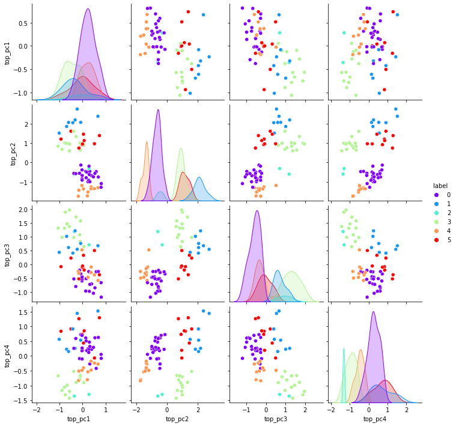

```python
df_top_major = x_top.loc[top_major] # 주성분분석 결과 중 주류 챔피언만 선택
# k-means
km = KMeans(n_clusters=6, random_state=0)
km_data = km.fit_transform(df_top_major)
print('실루엣 스코어:',silhouette_score(km_data, km.labels_))
labels = pd.DataFrame(data={'label':km.labels_},index=df_top_major.index) # 라벨링 결과 챔피언과 조인

for j in range(0,6):
    print('-'*10+'라벨 '+str(j)+'-'*10)
    print('군집 중심:',km.cluster_centers_[j])
    print('해당 챔피언 목록')
    print(labels[labels['label']==j].index.to_list())

res = pd.concat([labels, df_top_major], axis=1) # 결과 시각화 위해 조인
sns.pairplot(res, hue='label', palette='rainbow') # dpm, dtpm을 두 축으로 페어플롯
plt.show()
```

롤을 어느정도 플레이해본 유저라면 공감하겠지만, 롤 유저들 중 누가 보더라도 각 군집의 특성을 평가 할 수 있을 정도로 명확히 구분이 되어있다. 하지만 각 컬럼이 어떤 의미를 갖는지, 어떤 변수의 영향력이 큰지는 위의 페어플롯으론 확인이 불가능하다. 생성된 PCA객체의 고유벡터를 분석하여 원 데이터의 각 컬럼의 영향력을 확인 할 수 있겠으나, 우선 군집분석의 결과가 상당히 만족스러우므로 다른 포지션에 대한 PCA변환을 진행 후 모델설계를 진행하고자 한다.

```python
# 주성분 분석 결과 저장
with open("label_top2.pickle","wb") as fw:
    pickle.dump(x_top, fw)
```

```python
# PCA객체 저장
with open("pca_top.pickle","wb") as fw:
    pickle.dump(pca_top, fw)
```

### 2. 정글

#### 컬럼 선택

- 타워링 관련 컬럼 제외: damageDealtToTurrets
- 서포팅 관련 컬럼 제외: totalDamageShieldedOnTeammates, totalHealsOnTeammates, visionScore
- 라이너 관련 컬럼 제외: totalMinionsKilled
- 목적변수 제외: win
- 인덱스: teamPosition, championName

```python
# 컬럼 제외
df_jgl = df[df['teamPosition']=='JUNGLE']
df_jgl = df_jgl.drop(['teamPosition','damageDealtToTurrets','totalMinionsKilled','totalDamageShieldedOnTeammates','totalHealsOnTeammates','visionScore','win'],axis=1)
df_jgl.head() # 컬럼 14개(챔피언 이름 제외)
```

| matchId | gameDuration | assists | championName | damageDealtToObjectives | damageSelfMitigated | deaths | dragonKills | kills | magicDamageDealtToChampions | neutralMinionsKilled | physicalDamageDealtToChampions | timeCCingOthers | totalDamageDealtToChampions | totalDamageTaken | trueDamageDealtToChampions |
| --- | --- | --- | --- | --- | --- | --- | --- | --- | --- | --- | --- | --- | --- | --- | --- |
| KR_5944529373 | 1548 | 5 | Viego | 12425 | 13265 | 5 | 0 | 3 | 1112 | 96 | 8631 | 14 | 10543 | 20618 | 799 |
| KR_5944529373 | 1548 | 12 | Graves | 18991 | 9635 | 5 | 1 | 10 | 608 | 135 | 18832 | 15 | 20073 | 17053 | 632 |
| KR_5944532797 | 1858 | 8 | Evelynn | 22232 | 11795 | 3 | 3 | 13 | 25181 | 160 | 564 | 7 | 26605 | 19771 | 858 |
| KR_5944532797 | 1858 | 8 | MonkeyKing | 13149 | 33275 | 5 | 0 | 14 | 2971 | 118 | 14241 | 16 | 19458 | 29419 | 2245 |
| KR_5944532993 | 2094 | 10 | Kindred | 38479 | 13830 | 7 | 3 | 10 | 4442 | 113 | 18429 | 11 | 28224 | 24948 | 5352 |

```python
# 컬럼명 저장
with open("cols_jgl.pickle","wb") as fw:
    pickle.dump(df_jgl.drop('championName',axis=1).columns, fw)
```

```python
len(df_jgl) # 정글 챔피언 행 수
```

```
217008
```

```python
# 데이터 정규화
from sklearn.preprocessing import StandardScaler
x_jgl = df_jgl.drop('championName',axis=1).values # 분석에 사용될 값
columns = df_jgl.drop('championName',axis=1).columns

scaler_jgl = StandardScaler()
scaler_jgl.fit(x_jgl)
x_jgl = scaler_jgl.transform(x_jgl) # 표준화
pd.DataFrame(x_jgl, columns=columns).head() # 표준화된 데이터 확인
```

|  | gameDuration | assists | damageDealtToObjectives | damageSelfMitigated | deaths | dragonKills | kills | magicDamageDealtToChampions | neutralMinionsKilled | physicalDamageDealtToChampions | timeCCingOthers | totalDamageDealtToChampions | totalDamageTaken | trueDamageDealtToChampions |
| --- | --- | --- | --- | --- | --- | --- | --- | --- | --- | --- | --- | --- | --- | --- |
| 0 | -1.220826 | 0.569753 | -0.927752 | -1.051769 | -0.443592 | -1.337279 | -1.082670 | -0.675943 | -1.283130 | -0.336242 | -0.453213 | -1.101314 | -1.331852 | -0.584604 |
| 1 | -1.220826 | 2.143370 | -0.463536 | -1.263489 | -0.443592 | -0.484033 | 0.404408 | -0.727325 | -0.032666 | 0.695627 | -0.413861 | -0.161606 | -1.702759 | -0.664974 |
| 2 | -0.097262 | 1.244160 | -0.234398 | -1.137507 | -1.118253 | 1.222461 | 1.041726 | 1.777864 | 0.768913 | -1.152250 | -0.728674 | 0.482484 | -1.419975 | -0.556210 |
| 3 | -0.097262 | 1.244160 | -0.876565 | 0.115318 | -0.443592 | -1.337279 | 1.254166 | -0.486420 | -0.577740 | 0.231230 | -0.374509 | -0.222248 | -0.416187 | 0.111292 |
| 4 | 0.758097 | 1.693765 | 0.914264 | -1.018815 | 0.231069 | 1.222461 | 0.404408 | -0.336453 | -0.738056 | 0.654862 | -0.571268 | 0.642126 | -0.881355 | 1.606554 |

```python
# PCA 분석
from sklearn.decomposition import PCA
pcColumns = np.arange(1,11)
pca = PCA(n_components=10) # 주성분 10개
printcipalComponents = pca.fit(x_jgl)

print('각 설명변수별 설명력:',pca.explained_variance_ratio_)
print('총 설명력:',pca.explained_variance_ratio_.sum()) # 주성분의 갯수를 늘릴수록 100에 가까워짐
```

```
각 설명변수별 설명력: [0.30118621 0.14990525 0.11226746 0.09614817 0.0707355  0.06854995
 0.04987169 0.04432258 0.039625   0.02307099]
총 설명력: 0.9556827956931799
```

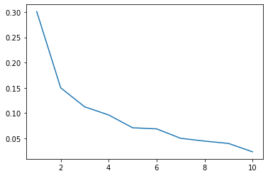

```python
# scree plot
# 주성분을 몇개로 할지 결정
sns.lineplot(x=pcColumns, y=pca.explained_variance_ratio_)
plt.show()
```

scree plot의 기울기가 급격히 감소하는 지점인 5개로 결정

```python
# 향후 챔피언별 통계값의 차원 축소를 위한 PCA객체
pca_jgl = PCA(n_components=5)
pca_jgl.fit(x_jgl)
print('각 설명변수별 설명력:',pca_jgl.explained_variance_ratio_)
print('총 설명력:',pca_jgl.explained_variance_ratio_.sum())
```

```
각 설명변수별 설명력: [0.30118621 0.14990525 0.11226746 0.09614817 0.0707355 ]
총 설명력: 0.730242587469759
```

```python
# 챔피언별 통계
df_jgl_champ = df_jgl.groupby('championName').mean()
df_jgl_champ.head()
```

| championName | gameDuration | assists | damageDealtToObjectives | damageSelfMitigated | deaths | dragonKills | kills | magicDamageDealtToChampions | neutralMinionsKilled | physicalDamageDealtToChampions | timeCCingOthers | totalDamageDealtToChampions | totalDamageTaken | trueDamageDealtToChampions |
| --- | --- | --- | --- | --- | --- | --- | --- | --- | --- | --- | --- | --- | --- | --- |
| Aatrox | 1865.908497 | 1.065359 | 25766.660131 | 35675.679739 | 6.183007 | 1.424837 | 8.405229 | 61.111111 | 141.784314 | 22009.228758 | 22.300654 | 23299.071895 | 38075.588235 | 1228.313725 |
| Akali | 1690.000000 | 0.000000 | 7355.000000 | 18284.000000 | 8.000000 | 0.000000 | 5.000000 | 8323.000000 | 101.000000 | 856.000000 | 1.000000 | 9799.000000 | 31643.000000 | 619.000000 |
| Akshan | 1891.842105 | 1.894737 | 18305.105263 | 19514.157895 | 8.263158 | 1.105263 | 9.052632 | 2668.526316 | 112.526316 | 16915.473684 | 6.421053 | 23293.052632 | 28436.263158 | 3707.947368 |
| Alistar | 1992.000000 | 0.000000 | 11948.500000 | 60314.000000 | 11.000000 | 1.000000 | 6.000000 | 15678.500000 | 48.000000 | 2032.500000 | 75.500000 | 19514.500000 | 45472.000000 | 1802.500000 |
| Amumu | 1901.434817 | 3.305238 | 22793.208744 | 33558.995668 | 6.234738 | 1.554549 | 5.808586 | 14155.187082 | 129.196928 | 1683.009059 | 42.386373 | 18753.761323 | 33416.991729 | 2914.564002 |

```python
# 챔피언별 통계 데이터 정규화 -> PCA
x_jgl = df_jgl_champ.values # 분석에 사용될 값
columns = ['jgl_pc1','jgl_pc2','jgl_pc3','jgl_pc4','jgl_pc5']
index = df_jgl_champ.index

x_jgl = scaler_jgl.transform(x_jgl) # fit 되어있는 스케일러로 표준화
x_jgl = pca_jgl.transform(x_jgl) # fit 되어있는 PCA객체로 차원 축소

x_jgl = pd.DataFrame(data=x_jgl, columns=columns, index=index)
x_jgl.head()
```

| championName | jgl_pc1 | jgl_pc2 | jgl_pc3 | jgl_pc4 | jgl_pc5 |
| --- | --- | --- | --- | --- | --- |
| Aatrox | 0.391337 | 0.082329 | -1.187444 | -0.287177 | -0.182149 |
| Akali | -2.769215 | 1.269032 | 0.357801 | 0.613017 | -0.705831 |
| Akshan | -0.484256 | 0.421432 | -1.003754 | 1.306397 | -0.377756 |
| Alistar | -0.210442 | 3.629512 | 0.888617 | -0.492036 | 1.214001 |
| Amumu | -0.339675 | 0.438284 | 1.152365 | -0.213225 | 0.388852 |

```python
from sklearn.cluster import KMeans
from sklearn.metrics import silhouette_score
```

```python
# 비주류 챔피언 제외
import pickle
with open("label_jgl.pickle","rb") as fr:
    label_jgl = pickle.load(fr)
jgl_major = label_jgl[label_jgl['jgl_비주류']==0].index
jgl_major # 주류 챔피언 리스트
```

```
Index(['Amumu', 'Belveth', 'Diana', 'Ekko', 'Elise', 'Evelynn', 'FiddleSticks',
       'Gragas', 'Graves', 'Hecarim', 'JarvanIV', 'Karthus', 'Kayn', 'Khazix',
       'Kindred', 'LeeSin', 'Lillia', 'MasterYi', 'MonkeyKing', 'Nidalee',
       'Nocturne', 'Nunu', 'Pantheon', 'Poppy', 'Qiyana', 'Rammus', 'RekSai',
       'Rengar', 'Sejuani', 'Shaco', 'Shyvana', 'Taliyah', 'Talon', 'Trundle',
       'Udyr', 'Vi', 'Viego', 'Volibear', 'Warwick', 'XinZhao', 'Zac', 'Zed',
       'Maokai', 'Mordekaiser', 'Jax', 'Twitch', 'Skarner'],
      dtype='object')
```

```
실루엣 스코어: 0.4199484134522981
----------라벨 0----------
군집 중심: [ 0.70299068  0.01747603  2.18998078  1.65546494 -0.09598133]
해당 챔피언 목록
['Karthus', 'Lillia']
----------라벨 1----------
군집 중심: [-0.00729704  0.14749875 -0.60373165 -0.47110212 -0.02282056]
해당 챔피언 목록
['Hecarim', 'JarvanIV', 'Kayn', 'LeeSin', 'MonkeyKing', 'Poppy', 'Trundle', 'Udyr', 'Vi', 'Viego', 'XinZhao', 'Jax']
----------라벨 2----------
군집 중심: [-0.1960302  -0.11259187  1.5109817   0.44640538 -0.02835725]
해당 챔피언 목록
['Diana', 'Ekko', 'Elise', 'Evelynn', 'FiddleSticks', 'Gragas', 'Nidalee', 'Shaco', 'Shyvana', 'Taliyah', 'Mordekaiser']
----------라벨 3----------
군집 중심: [ 0.62344142  1.03083529 -0.44084097 -2.01644885  4.2221253 ]
해당 챔피언 목록
['Nocturne']
----------라벨 4----------
군집 중심: [ 0.20920041 -0.33701754 -1.01671771  0.60466179 -0.22970444]
해당 챔피언 목록
['Belveth', 'Graves', 'Khazix', 'Kindred', 'MasterYi', 'Pantheon', 'Qiyana', 'RekSai', 'Rengar', 'Talon', 'Zed', 'Twitch']
----------라벨 5----------
군집 중심: [-0.30476204  0.69055976  0.799256   -0.87771233  0.53750385]
해당 챔피언 목록
['Amumu', 'Nunu', 'Rammus', 'Sejuani', 'Volibear', 'Warwick', 'Zac', 'Maokai', 'Skarner']
```

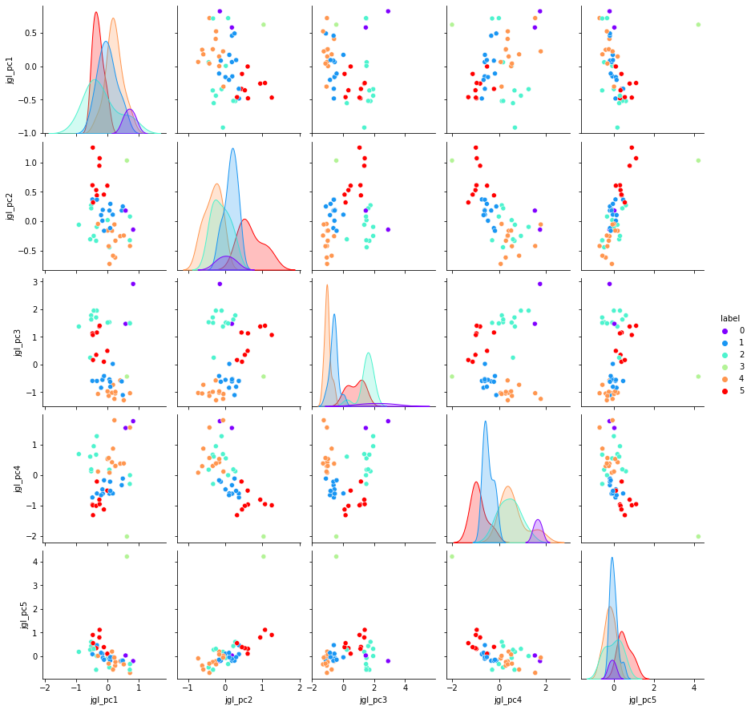

```python
df_jgl_major = x_jgl.loc[jgl_major] # 주성분분석 결과 중 주류 챔피언만 선택
# k-means
km = KMeans(n_clusters=6, random_state=0)
km_data = km.fit_transform(df_jgl_major)
print('실루엣 스코어:',silhouette_score(km_data, km.labels_))
labels = pd.DataFrame(data={'label':km.labels_},index=df_jgl_major.index) # 라벨링 결과 챔피언과 조인

for j in range(0,6):
    print('-'*10+'라벨 '+str(j)+'-'*10)
    print('군집 중심:',km.cluster_centers_[j])
    print('해당 챔피언 목록')
    print(labels[labels['label']==j].index.to_list())

res = pd.concat([labels, df_jgl_major], axis=1) # 결과 시각화 위해 조인
sns.pairplot(res, hue='label', palette='rainbow') # dpm, dtpm을 두 축으로 페어플롯
plt.show()
```

역시 탑의 경우와 마찬가지로 만족스러운 군집 분석이다.

```python
# 주성분 분석 결과 저장
with open("label_jgl2.pickle","wb") as fw:
    pickle.dump(x_jgl, fw)
```

```python
# PCA객체 저장
with open("pca_jgl.pickle","wb") as fw:
    pickle.dump(pca_jgl, fw)
```

### 3. 미드

#### 컬럼 선택

- 오브젝트 관련 컬럼 제외: damageDealtToObjectives, dragonKills
- 서포팅 관련 컬럼 제외: totalDamageShieldedOnTeammates, totalHealsOnTeammates, visionScore
- 목적변수 제외: win
- 인덱스: teamPosition, championName

```python
# 컬럼 제외
df_mid = df[df['teamPosition']=='MIDDLE']
df_mid = df_mid.drop(['teamPosition','damageDealtToObjectives','dragonKills','totalDamageShieldedOnTeammates','totalHealsOnTeammates','visionScore','win'],axis=1)
df_mid.head() # 컬럼 14개(챔피언 이름 제외)
```

| matchId | gameDuration | assists | championName | damageDealtToTurrets | damageSelfMitigated | deaths | kills | magicDamageDealtToChampions | neutralMinionsKilled | physicalDamageDealtToChampions | timeCCingOthers | totalDamageDealtToChampions | totalDamageTaken | totalMinionsKilled | trueDamageDealtToChampions |
| --- | --- | --- | --- | --- | --- | --- | --- | --- | --- | --- | --- | --- | --- | --- | --- |
| KR_5944529373 | 1548 | 1 | Katarina | 0 | 13089 | 6 | 7 | 14299 | 8 | 4636 | 1 | 19362 | 22430 | 142 | 426 |
| KR_5944529373 | 1548 | 7 | Sett | 4106 | 19265 | 2 | 6 | 0 | 24 | 13622 | 26 | 17921 | 22166 | 179 | 4298 |
| KR_5944532797 | 1858 | 11 | Vladimir | 5042 | 13927 | 3 | 10 | 24133 | 15 | 855 | 3 | 26957 | 24349 | 245 | 1969 |
| KR_5944532797 | 1858 | 11 | Ahri | 1380 | 10522 | 11 | 2 | 12720 | 0 | 1347 | 24 | 20911 | 30916 | 150 | 6843 |
| KR_5944532993 | 2094 | 6 | Leblanc | 813 | 12078 | 8 | 4 | 16884 | 8 | 1581 | 13 | 19867 | 23779 | 163 | 1401 |

```python
len(df_mid) # 미드 챔피언 행 수
```

```
217008
```

```python
# 데이터 정규화
from sklearn.preprocessing import StandardScaler
x_mid = df_mid.drop('championName',axis=1).values # 분석에 사용될 값
columns = df_mid.drop('championName',axis=1).columns

scaler_mid = StandardScaler()
scaler_mid.fit(x_mid)
x_mid = scaler_mid.transform(x_mid) # 표준화
pd.DataFrame(x_mid, columns=columns).head() # 표준화된 데이터 확인
```

|  | gameDuration | assists | damageDealtToTurrets | damageSelfMitigated | deaths | kills | magicDamageDealtToChampions | neutralMinionsKilled | physicalDamageDealtToChampions | timeCCingOthers | totalDamageDealtToChampions | totalDamageTaken | totalMinionsKilled | trueDamageDealtToChampions |
| --- | --- | --- | --- | --- | --- | --- | --- | --- | --- | --- | --- | --- | --- | --- |
| 0 | -1.220826 | -0.204916 | -1.061246 | -0.582268 | -0.130906 | -0.010492 | -0.130511 | -0.325405 | -0.207137 | -1.342172 | -0.456100 | -0.403393 | -1.028260 | -0.700487 |
| 1 | -1.220826 | 1.317478 | 0.401132 | -0.098218 | -1.475610 | -0.238966 | -1.357681 | 1.068760 | 0.767767 | 0.110581 | -0.595901 | -0.432229 | -0.125136 | 1.432736 |
| 2 | -0.097262 | 2.332407 | 0.734495 | -0.516589 | -1.139434 | 0.674932 | 0.713464 | 0.284542 | -0.617344 | -1.225952 | 0.280739 | -0.193788 | 1.485841 | 0.149607 |
| 3 | -0.097262 | 2.332407 | -0.569750 | -0.783460 | 1.549975 | -1.152864 | -0.266024 | -1.022487 | -0.563966 | -0.005640 | -0.305822 | 0.523502 | -0.832990 | 2.834868 |
| 4 | 0.758097 | 1.063746 | -0.771691 | -0.661506 | 0.541447 | -0.695915 | 0.091339 | -0.325405 | -0.538579 | -0.644851 | -0.407107 | -0.256047 | -0.515676 | -0.163324 |

```python
# PCA 분석
from sklearn.decomposition import PCA
pcColumns = np.arange(1,11)
pca = PCA(n_components=10) # 주성분 10개
printcipalComponents = pca.fit(x_mid)

print('각 설명변수별 설명력:',pca.explained_variance_ratio_)
print('총 설명력:',pca.explained_variance_ratio_.sum()) # 주성분의 갯수를 늘릴수록 100에 가까워짐
```

```
각 설명변수별 설명력: [0.29587155 0.13866577 0.12354579 0.0770734  0.07268466 0.06006108
 0.05788612 0.05009114 0.04315749 0.03476952]
총 설명력: 0.9538065275389126
```

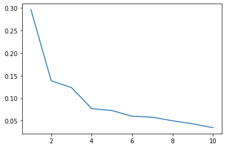

```python
# scree plot
# 주성분을 몇개로 할지 결정
sns.lineplot(x=pcColumns, y=pca.explained_variance_ratio_)
plt.show()
```

scree plot의 기울기가 급격히 감소하는 지점인 4개로 결정

```python
# 향후 챔피언별 통계값의 차원 축소를 위한 PCA객체
pca_mid = PCA(n_components=4)
pca_mid.fit(x_mid)
print('각 설명변수별 설명력:',pca_mid.explained_variance_ratio_)
print('총 설명력:',pca_mid.explained_variance_ratio_.sum())
```

```
각 설명변수별 설명력: [0.29587155 0.13866577 0.12354579 0.0770734 ]
총 설명력: 0.6351565048374809
```

```python
# 챔피언별 통계
df_mid_champ = df_mid.groupby('championName').mean()
df_mid_champ.head()
```

| championName | gameDuration | assists | damageDealtToTurrets | damageSelfMitigated | deaths | kills | magicDamageDealtToChampions | neutralMinionsKilled | physicalDamageDealtToChampions | timeCCingOthers | totalDamageDealtToChampions | totalDamageTaken | totalMinionsKilled | trueDamageDealtToChampions |
| --- | --- | --- | --- | --- | --- | --- | --- | --- | --- | --- | --- | --- | --- | --- |
| Aatrox | 1851.904021 | 0.894942 | 3059.560311 | 35524.932555 | 6.273671 | 6.989624 | 91.600519 | 15.430610 | 22740.341115 | 22.939040 | 23806.597925 | 35501.457847 | 174.160830 | 974.252918 |
| Ahri | 1889.539437 | 2.849335 | 2611.827999 | 12131.008657 | 5.580098 | 6.044509 | 14927.700332 | 6.902763 | 1761.861577 | 25.726303 | 21883.742830 | 23157.321004 | 183.934593 | 5193.184680 |
| Akali | 1891.284710 | 1.198594 | 1757.920584 | 19251.162346 | 6.049649 | 8.654218 | 21932.439807 | 5.323484 | 1399.354350 | 1.894991 | 24572.171463 | 29270.466608 | 167.473199 | 1239.549868 |
| Akshan | 1880.426396 | 1.320968 | 4128.563842 | 19025.861773 | 6.992581 | 8.882077 | 3424.042171 | 11.479110 | 19927.136665 | 2.312378 | 25372.392815 | 23827.031238 | 183.843811 | 2020.322530 |
| Alistar | 1883.818182 | 0.454545 | 836.636364 | 45065.545455 | 6.818182 | 3.090909 | 10779.727273 | 12.181818 | 1303.272727 | 47.727273 | 13312.272727 | 30817.000000 | 97.090909 | 1228.363636 |

```python
# 챔피언별 통계 데이터 정규화 -> PCA
x_mid = df_mid_champ.values # 분석에 사용될 값
columns = ['mid_pc1','mid_pc2','mid_pc3','mid_pc4']
index = df_mid_champ.index

x_mid = scaler_mid.transform(x_mid) # fit 되어있는 스케일러로 표준화
x_mid = pca_mid.transform(x_mid) # fit 되어있는 PCA객체로 차원 축소

x_mid = pd.DataFrame(data=x_mid, columns=columns, index=index)
x_mid.head()
```

| championName | mid_pc1 | mid_pc2 | mid_pc3 | mid_pc4 |
| --- | --- | --- | --- | --- |
| Aatrox | 0.745454 | -2.248134 | -0.477114 | -0.043177 |
| Ahri | -0.305748 | 0.356849 | 0.170739 | 0.062447 |
| Akali | -0.391534 | 0.405537 | -0.189153 | 0.974269 |
| Akshan | 0.090214 | -1.941095 | 0.629958 | 0.674422 |
| Alistar | -0.584925 | -0.082513 | -2.261205 | -0.304896 |

PCA결과 군집화 및 시각화 생략

```python
# 주성분 분석 결과 저장
with open("label_mid2.pickle","wb") as fw:
    pickle.dump(x_mid, fw)
```

```python
# PCA객체 저장
with open("pca_mid.pickle","wb") as fw:
    pickle.dump(pca_mid, fw)
```

### 4. 바텀(원딜)

#### 컬럼 선택

- 오브젝트 관련 컬럼 제외: damageDealtToObjectives, dragonKills
- 서포팅 관련 컬럼 제외: totalDamageShieldedOnTeammates, totalHealsOnTeammates, visionScore
- 스플릿 푸시 관련 컬럼 제외: neutralMinionsKilled
- 목적변수 제외: win
- 인덱스: teamPosition, championName

```python
# 컬럼 제외
df_bot = df[df['teamPosition']=='BOTTOM']
df_bot = df_bot.drop(['teamPosition','damageDealtToObjectives','neutralMinionsKilled','dragonKills','totalDamageShieldedOnTeammates','totalHealsOnTeammates','visionScore','win'],axis=1)
df_bot.head() # 컬럼 13개(챔피언 이름 제외)
```

| matchId | gameDuration | assists | championName | damageDealtToTurrets | damageSelfMitigated | deaths | kills | magicDamageDealtToChampions | physicalDamageDealtToChampions | timeCCingOthers | totalDamageDealtToChampions | totalDamageTaken | totalMinionsKilled | trueDamageDealtToChampions |
| --- | --- | --- | --- | --- | --- | --- | --- | --- | --- | --- | --- | --- | --- | --- |
| KR_5944529373 | 1548 | 2 | Tristana | 248 | 8841 | 6 | 5 | 1986 | 8145 | 2 | 10721 | 19263 | 168 | 588 |
| KR_5944529373 | 1548 | 14 | Zeri | 5436 | 7847 | 5 | 4 | 5851 | 12376 | 12 | 19039 | 13408 | 139 | 812 |
| KR_5944532797 | 1858 | 11 | Jinx | 4198 | 11883 | 7 | 9 | 861 | 23247 | 19 | 27872 | 19321 | 189 | 3764 |
| KR_5944532797 | 1858 | 5 | Lucian | 1216 | 12402 | 10 | 8 | 2331 | 18091 | 0 | 22604 | 27156 | 209 | 2182 |
| KR_5944532993 | 2094 | 13 | MissFortune | 3146 | 9394 | 4 | 3 | 5464 | 30265 | 23 | 36781 | 15314 | 209 | 1050 |

```python
# 컬럼명 저장
with open("cols_bot.pickle","wb") as fw:
    pickle.dump(df_bot.drop('championName',axis=1).columns, fw)
```

```python
len(df_mid) # 원딜 챔피언 행 수
```

```
217008
```

```python
# 데이터 정규화
from sklearn.preprocessing import StandardScaler
x_bot = df_bot.drop('championName',axis=1).values # 분석에 사용될 값
columns = df_bot.drop('championName',axis=1).columns

scaler_bot = StandardScaler()
scaler_bot.fit(x_bot)
x_bot = scaler_bot.transform(x_bot) # 표준화
pd.DataFrame(x_bot, columns=columns).head() # 표준화된 데이터 확인
```

|  | gameDuration | assists | damageDealtToTurrets | damageSelfMitigated | deaths | kills | magicDamageDealtToChampions | physicalDamageDealtToChampions | timeCCingOthers | totalDamageDealtToChampions | totalDamageTaken | totalMinionsKilled | trueDamageDealtToChampions |
| --- | --- | --- | --- | --- | --- | --- | --- | --- | --- | --- | --- | --- | --- |
| 0 | -1.220826 | 0.021071 | -1.211305 | -0.673078 | -0.150140 | -0.648618 | -0.469983 | -1.120191 | -0.767226 | -1.228405 | -0.484566 | -0.875230 | -0.526930 |
| 1 | -1.220826 | 3.037251 | 0.277452 | -0.807467 | -0.492853 | -0.841598 | 0.248092 | -0.679571 | -0.035665 | -0.517646 | -1.285310 | -1.567850 | -0.418742 |
| 2 | -0.097262 | 2.283206 | -0.077806 | -0.261799 | 0.192572 | 0.123300 | -0.678996 | 0.452545 | 0.476428 | 0.237118 | -0.476634 | -0.373678 | 1.007013 |
| 3 | -0.097262 | 0.775116 | -0.933526 | -0.191630 | 1.220709 | -0.069680 | -0.405886 | -0.084406 | -0.913539 | -0.213023 | 0.594899 | 0.103991 | 0.242939 |
| 4 | 0.758097 | 2.785903 | -0.379690 | -0.598313 | -0.835565 | -1.034577 | 0.176192 | 1.183406 | 0.769053 | 0.998376 | -1.024641 | 0.103991 | -0.303793 |

```python
# PCA 분석
from sklearn.decomposition import PCA
pcColumns = np.arange(1,11)
pca = PCA(n_components=10) # 주성분 10개
printcipalComponents = pca.fit(x_bot)

print('각 설명변수별 설명력:',pca.explained_variance_ratio_)
print('총 설명력:',pca.explained_variance_ratio_.sum()) # 주성분의 갯수를 늘릴수록 100에 가까워짐
```

```
각 설명변수별 설명력: [0.36758606 0.14409011 0.09358371 0.07932822 0.07096765 0.0686011
 0.05395625 0.04221948 0.03633071 0.01784219]
총 설명력: 0.9745054792442219
```

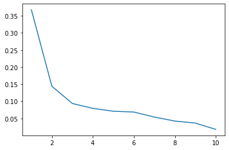

```python
# scree plot
# 주성분을 몇개로 할지 결정
sns.lineplot(x=pcColumns, y=pca.explained_variance_ratio_)
plt.show()
```

scree plot의 기울기가 급격히 감소하는 지점인 3개로 결정

```python
# 향후 챔피언별 통계값의 차원 축소를 위한 PCA객체
pca_bot = PCA(n_components=3)
pca_bot.fit(x_bot)
print('각 설명변수별 설명력:',pca_bot.explained_variance_ratio_)
print('총 설명력:',pca_bot.explained_variance_ratio_.sum())
```

```
각 설명변수별 설명력: [0.36758606 0.14409011 0.09358371]
총 설명력: 0.6052598779944274
```

```python
# 챔피언별 통계
df_bot_champ = df_bot.groupby('championName').mean()
df_bot_champ.head()
```

| championName | gameDuration | assists | damageDealtToTurrets | damageSelfMitigated | deaths | kills | magicDamageDealtToChampions | physicalDamageDealtToChampions | timeCCingOthers | totalDamageDealtToChampions | totalDamageTaken | totalMinionsKilled | trueDamageDealtToChampions |
| --- | --- | --- | --- | --- | --- | --- | --- | --- | --- | --- | --- | --- | --- |
| Aatrox | 1848.466667 | 1.933333 | 2902.333333 | 35464.266667 | 6.333333 | 8.133333 | 279.066667 | 22691.400000 | 26.400000 | 23841.200000 | 35166.733333 | 154.666667 | 870.266667 |
| Ahri | 1990.200000 | 2.550000 | 2837.000000 | 12407.700000 | 7.200000 | 5.800000 | 13596.700000 | 2375.100000 | 25.500000 | 21398.650000 | 24606.750000 | 182.750000 | 5425.850000 |
| Akali | 1838.600000 | 2.800000 | 1629.900000 | 17744.100000 | 5.800000 | 9.800000 | 21439.100000 | 1919.400000 | 3.000000 | 24553.900000 | 28093.600000 | 145.800000 | 1194.300000 |
| Akshan | 1941.253968 | 1.317460 | 3395.650794 | 18025.873016 | 7.634921 | 8.746032 | 2824.777778 | 18425.555556 | 3.380952 | 23141.650794 | 24330.650794 | 180.285714 | 1890.380952 |
| Alistar | 1860.142857 | 6.714286 | 1179.285714 | 36786.571429 | 7.285714 | 2.142857 | 8496.714286 | 1083.428571 | 49.857143 | 10238.857143 | 29403.285714 | 69.571429 | 658.142857 |

```python
# 챔피언별 통계 데이터 정규화 -> PCA
x_bot = df_bot_champ.values # 분석에 사용될 값
columns = ['bot_pc1','bot_pc2','bot_pc3']
index = df_bot_champ.index

x_bot = scaler_bot.transform(x_bot) # fit 되어있는 스케일러로 표준화
x_bot = pca_bot.transform(x_bot) # fit 되어있는 PCA객체로 차원 축소

x_bot = pd.DataFrame(data=x_bot, columns=columns, index=index)
x_bot.head()
```

| championName | bot_pc1 | bot_pc2 | bot_pc3 |
| --- | --- | --- | --- |
| Aatrox | 1.140995 | 1.820681 | 0.078121 |
| Ahri | -0.135009 | 1.051632 | 1.402074 |
| Akali | -0.385714 | 1.162104 | 2.153905 |
| Akshan | 0.003819 | 0.656901 | -0.622057 |
| Alistar | -0.856586 | 3.521171 | 3.076065 |

PCA결과 군집화 및 시각화 생략

```python
# 주성분 분석 결과 저장
with open("label_bot2.pickle","wb") as fw:
    pickle.dump(x_bot, fw)
```

```python
# PCA객체 저장
with open("pca_bot.pickle","wb") as fw:
    pickle.dump(pca_bot, fw)
```

### . 바텀(서폿)

#### 컬럼 선택

- 오브젝트 관련 컬럼 제외: damageDealtToObjectives, dragonKills
- 스플릿 푸시 관련 컬럼 제외: damageDealtToTurrets, neutralMinionsKilled
- cs관련 컬럼 제외: totalMinionsKilled
- 목적변수 제외: win
- 인덱스: teamPosition, championName

```python
# 컬럼 제외
df_sup = df[df['teamPosition']=='UTILITY']
df_sup = df_sup.drop(['teamPosition','damageDealtToObjectives','neutralMinionsKilled','dragonKills','damageDealtToTurrets','totalMinionsKilled','win'],axis=1)
df_sup.head() # 컬럼 14개(챔피언 이름 제외)
```

| matchId | gameDuration | assists | championName | damageSelfMitigated | deaths | kills | magicDamageDealtToChampions | physicalDamageDealtToChampions | timeCCingOthers | totalDamageDealtToChampions | totalDamageShieldedOnTeammates | totalDamageTaken | totalHealsOnTeammates | trueDamageDealtToChampions | visionScore |
| --- | --- | --- | --- | --- | --- | --- | --- | --- | --- | --- | --- | --- | --- | --- | --- |
| KR_5944529373 | 1548 | 9 | Nautilus | 21768 | 7 | 0 | 4585 | 2608 | 59 | 7656 | 536 | 19286 | 0 | 461 | 48 |
| KR_5944529373 | 1548 | 17 | Zilean | 8253 | 4 | 2 | 7342 | 1607 | 21 | 9377 | 186 | 17549 | 0 | 427 | 50 |
| KR_5944532797 | 1858 | 22 | Seraphine | 10596 | 8 | 1 | 12223 | 2081 | 43 | 15368 | 2880 | 16135 | 2720 | 1063 | 65 |
| KR_5944532797 | 1858 | 16 | Zilean | 14591 | 11 | 1 | 6063 | 989 | 17 | 8317 | 0 | 32669 | 2076 | 1264 | 58 |
| KR_5944532993 | 2094 | 11 | Nautilus | 29068 | 7 | 4 | 7173 | 1807 | 64 | 9781 | 1045 | 20885 | 0 | 800 | 73 |

```python
len(df_sup) # 서폿 챔피언 행 수
```

```
217008
```

```python
# 데이터 정규화
from sklearn.preprocessing import StandardScaler
x_sup = df_sup.drop('championName',axis=1).values # 분석에 사용될 값
columns = df_sup.drop('championName',axis=1).columns

scaler_sup = StandardScaler()
scaler_sup.fit(x_sup)
x_sup = scaler_sup.transform(x_sup) # 표준화
pd.DataFrame(x_sup, columns=columns).head() # 표준화된 데이터 확인
```

|  | gameDuration | assists | damageSelfMitigated | deaths | kills | magicDamageDealtToChampions | physicalDamageDealtToChampions | timeCCingOthers | totalDamageDealtToChampions | totalDamageShieldedOnTeammates | totalDamageTaken | totalHealsOnTeammates | trueDamageDealtToChampions | visionScore |
| --- | --- | --- | --- | --- | --- | --- | --- | --- | --- | --- | --- | --- | --- | --- |
| 0 | -1.220826 | 0.841502 | 0.463236 | 0.064835 | -1.080969 | -0.584961 | -0.096129 | 1.152304 | -0.699548 | -0.474698 | -0.148906 | -0.448690 | -0.580607 | -0.740377 |
| 1 | -1.220826 | 2.014208 | -0.689937 | -0.890938 | -0.333852 | -0.208628 | -0.302905 | -0.960897 | -0.477025 | -0.634985 | -0.371195 | -0.448690 | -0.610483 | -0.648488 |
| 2 | -0.097262 | 2.747149 | -0.490019 | 0.383425 | -0.707411 | 0.457633 | -0.204991 | 0.262535 | 0.297606 | 0.598768 | -0.552149 | 0.200284 | -0.051610 | 0.040676 |
| 3 | -0.097262 | 1.867619 | -0.149144 | 1.339198 | -0.707411 | -0.383212 | -0.430564 | -1.183339 | -0.614082 | -0.720166 | 1.563757 | 0.046630 | 0.125015 | -0.280934 |
| 4 | 0.758097 | 1.134678 | 1.086112 | 0.064835 | 0.413264 | -0.231696 | -0.261591 | 1.430356 | -0.424788 | -0.241594 | 0.055723 | -0.448690 | -0.282717 | 0.408231 |

```python
# PCA 분석
from sklearn.decomposition import PCA
pcColumns = np.arange(1,11)
pca = PCA(n_components=10) # 주성분 10개
printcipalComponents = pca.fit(x_sup)

print('각 설명변수별 설명력:',pca.explained_variance_ratio_)
print('총 설명력:',pca.explained_variance_ratio_.sum()) # 주성분의 갯수를 늘릴수록 100에 가까워짐
```

```
각 설명변수별 설명력: [0.26449516 0.14441005 0.11583863 0.09773948 0.06896951 0.06513754
 0.05973525 0.05300406 0.04645234 0.03607536]
총 설명력: 0.9518573820460521
```

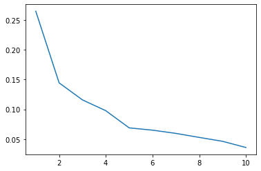

```python
# scree plot
# 주성분을 몇개로 할지 결정
sns.lineplot(x=pcColumns, y=pca.explained_variance_ratio_)
plt.show()
```

scree plot의 기울기가 급격히 감소하는 지점인 5개로 결정

```python
# 향후 챔피언별 통계값의 차원 축소를 위한 PCA객체
pca_sup = PCA(n_components=5)
pca_sup.fit(x_sup)
print('각 설명변수별 설명력:',pca_sup.explained_variance_ratio_)
print('총 설명력:',pca_sup.explained_variance_ratio_.sum())
```

```
각 설명변수별 설명력: [0.26449516 0.14441005 0.11583863 0.09773948 0.06896951]
총 설명력: 0.6914528209012445
```

```python
# 챔피언별 통계
df_sup_champ = df_sup.groupby('championName').mean()
df_sup_champ.head()
```

| championName | gameDuration | assists | damageSelfMitigated | deaths | kills | magicDamageDealtToChampions | physicalDamageDealtToChampions | timeCCingOthers | totalDamageDealtToChampions | totalDamageShieldedOnTeammates | totalDamageTaken | totalHealsOnTeammates | trueDamageDealtToChampions | visionScore |
| --- | --- | --- | --- | --- | --- | --- | --- | --- | --- | --- | --- | --- | --- | --- |
| Aatrox | 1836.490000 | 0.180000 | 24186.370000 | 8.690000 | 4.290000 | 83.820000 | 14886.020000 | 26.560000 | 15955.420000 | 4.850000 | 30587.850000 | 6.280000 | 985.060000 | 58.140000 |
| Ahri | 1899.396341 | 3.414634 | 9248.896341 | 7.103659 | 4.414634 | 11771.652439 | 1295.176829 | 31.170732 | 18168.798780 | 0.000000 | 21193.926829 | 17.506098 | 5100.884146 | 66.170732 |
| Akali | 1960.222222 | 0.555556 | 16708.555556 | 6.777778 | 7.555556 | 17084.444444 | 1331.000000 | 2.000000 | 19896.555556 | 0.000000 | 28358.111111 | 0.000000 | 1480.444444 | 54.000000 |
| Akshan | 1881.409091 | 1.340909 | 13875.022727 | 8.795455 | 8.272727 | 2232.772727 | 16795.204545 | 2.318182 | 20798.181818 | 0.000000 | 21525.204545 | 0.000000 | 1769.272727 | 59.681818 |
| Alistar | 1862.458360 | 3.489403 | 39314.411047 | 6.981374 | 1.655320 | 6356.162492 | 1043.936630 | 50.792336 | 8305.687219 | 633.796403 | 27290.124813 | 5492.888675 | 904.780133 | 58.758510 |

```python
# 챔피언별 통계 데이터 정규화 -> PCA
x_sup = df_sup_champ.values # 분석에 사용될 값
columns = ['sup_pc1','sup_pc2','sup_pc3','sup_pc4','sup_pc5']
index = df_sup_champ.index

x_sup = scaler_sup.transform(x_sup) # fit 되어있는 스케일러로 표준화
x_sup = pca_sup.transform(x_sup) # fit 되어있는 PCA객체로 차원 축소

x_sup = pd.DataFrame(data=x_sup, columns=columns, index=index)
x_sup.head()
```

| championName | sup_pc1 | sup_pc2 | sup_pc3 | sup_pc4 | sup_pc5 |
| --- | --- | --- | --- | --- | --- |
| Aatrox | 0.962719 | -0.498569 | -2.074528 | 2.030804 | -0.228912 |
| Ahri | 1.367710 | 1.547029 | -0.598181 | 0.053437 | -0.574779 |
| Akali | 0.980773 | 1.581033 | -0.780004 | -0.565169 | -0.703448 |
| Akshan | 0.898371 | 1.637576 | -2.030328 | 2.815793 | -0.641801 |
| Alistar | 0.412328 | -1.911108 | -0.121848 | -0.349400 | 0.593815 |

PCA결과 군집화 및 시각화 생략

```python
# 주성분 분석 결과 저장
with open("label_sup2.pickle","wb") as fw:
    pickle.dump(x_sup, fw)
```

```python
# PCA객체 저장
with open("pca_sup.pickle","wb") as fw:
    pickle.dump(pca_sup, fw)
```

포지션, 챔피언 별로 시행한 PCA 데이터로 예측 모델에 학습을 시킬 예정